# Regression and Other Stories: Residuals

Laura Kapitula

2021-11-02

Plotting the data and fitted model. See Chapter 11 in Regression and Other Stories. Edited version of original file by: Andrew Gelman, Jennifer Hill, Aki Vehtari

#### Load packages

```r
library("rstanarm")
library(tidyverse)
```

## Simple model with const term, one pre-treatment predictor, and treatment indicator

#### Fake data

```r
N <- 100
x <- runif(N, 0, 1)
z <- sample(c(0, 1), N, replace=TRUE)
a <- 1
b <- 2
theta <- 5
sigma <- 2
y <- a + b*x + theta*z +  rnorm(N, 0, sigma)
fake <- data.frame(x=x, y=y, z=z)
summary(fake)
```

```
       x                 y                z
 Min.   :0.01562   Min.   :-1.268   Min.   :0.00
 1st Qu.:0.30211   1st Qu.: 1.765   1st Qu.:0.00
 Median :0.53584   Median : 4.514   Median :0.00
 Mean   :0.52597   Mean   : 4.416   Mean   :0.47
 3rd Qu.:0.71118   3rd Qu.: 6.971   3rd Qu.:1.00
 Max.   :0.99975   Max.   :12.936   Max.   :1.00
```

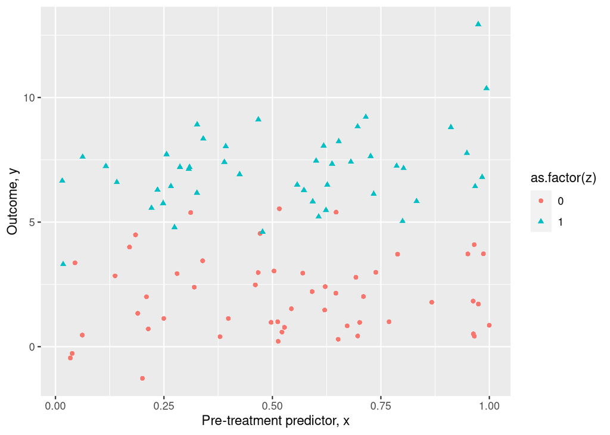

```r
ggplot(fake, aes(x=x, y=y, shape=as.factor(z), color=as.factor(z)) )+
  geom_point() +
    labs(x = "Pre-treatment predictor, x", y = "Outcome, y")
```

#### Model

```r
fit <- stan_glm(y ~ x + z, data=fake, refresh = 0)
print(fit)
```

```
stan_glm
 family:       gaussian [identity]
 formula:      y ~ x + z
 observations: 100
 predictors:   3
------
            Median MAD_SD
(Intercept) 1.4    0.4
x           1.2    0.6
z           5.1    0.3

Auxiliary parameter(s):
      Median MAD_SD
sigma 1.6    0.1

------
* For help interpreting the printed output see ?print.stanreg
* For info on the priors used see ?prior_summary.stanreg
```

#### Add predicted lines to our plot.

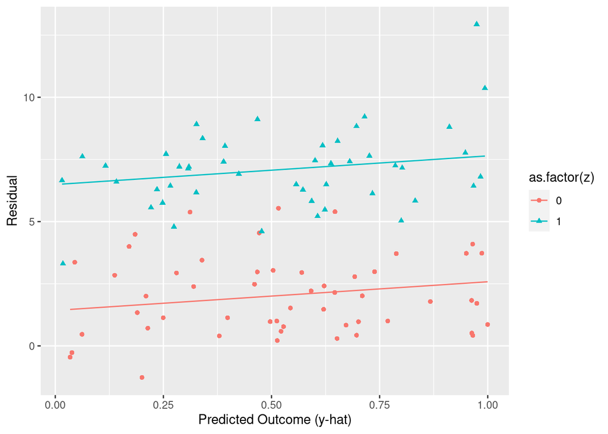

```r
#predicted is the y-hats, predicted values, using the model
#then we calculate the residuals as the actual value - the predicted value.
fake2 <- fake %>%
  mutate(predicted=predict(fit), resid=y-predict(fit))
ggplot(fake2, aes(x=x, y=y, shape=as.factor(z), color=as.factor(z)) )+
  geom_point() +
  geom_line(aes(x=x, y=predicted, shape=as.factor(z), color=as.factor(z))) +
 xlab("Predicted Outcome (y-hat)") + ylab("Residual")
```

#### Create a Residual Plot

In general it is good practice to plot the residuals vs. the fitted values. Below is all on one plot.

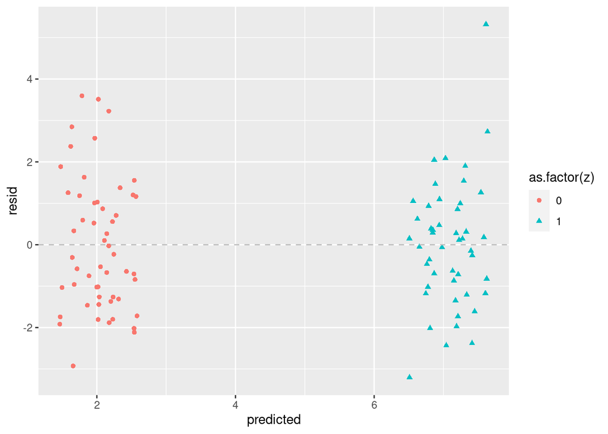

```r
#predicted is the y-hats, predicted values, using the model
#then we calculate the residuals as the actual value - the predicted value.

ggplot(fake2, aes(x=predicted, y=resid, shape=as.factor(z), color=as.factor(z)) )+
  geom_point() +
  geom_hline(yintercept=0, linetype="dashed", color = "gray")
```

We also could make this graph as a facet graph. Note that I am rewriting the book code using ggplot but I am fine with you coding your plots and things either way.

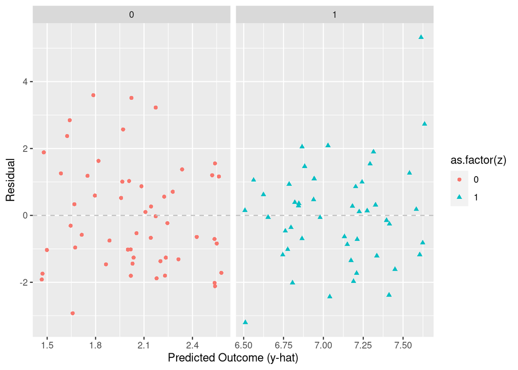

```r
#predicted is the y-hats, predicted values, using the model
#then we calculate the residuals as the actual value - the predicted value.

ggplot(fake2, aes(x=predicted, y=resid, shape=as.factor(z), color=as.factor(z)) )+
  geom_point() +
  geom_hline(yintercept=0, linetype="dashed", color = "gray") +
  facet_grid(. ~ as.factor(z), scales="free_x") +
 xlab("Predicted Outcome (y-hat)") + ylab("Residual")
```

Below is the book way.

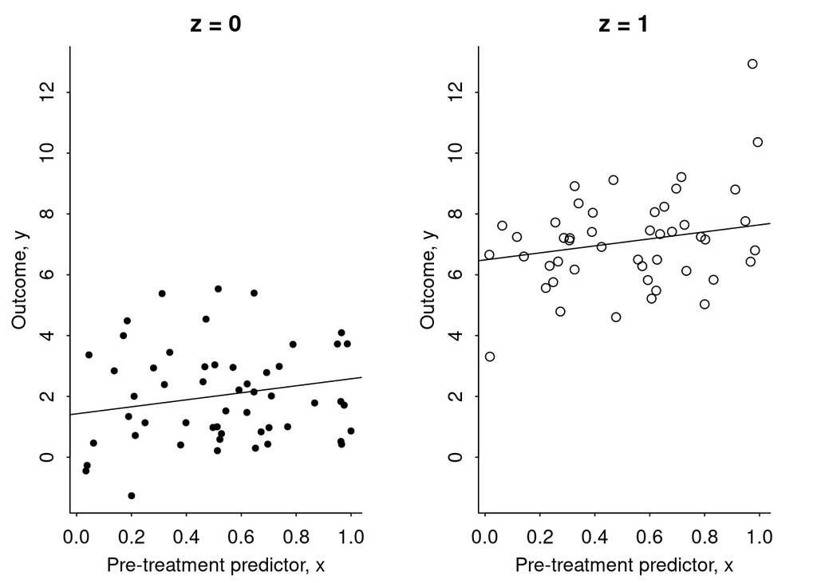

```r
par(mfrow=c(1,2), mar=c(3,3,2,2), mgp=c(1.7,.5,0), tck=-.01)
for (i in 0:1){
  plot(range(x), range(y), type="n", xlab="Pre-treatment predictor, x", ylab="Outcome, y", main=paste("z =", i), bty="l")
  points(x[z==i], y[z==i], pch=20+i)
  abline(coef(fit)["(Intercept)"] + coef(fit)["z"]*i, coef(fit)["x"])
}
```

## More complicated model with multiple pre-treatment predictors.

#### Fake data

In this section we extend the model where we have K predictors. The true model is:

$$y = b_o + b_1x_1 + ... + b_kx_k + \theta z + error$$
Where z is binary. Below is our code to generate fake data.

```r
N <- 100
K <- 10
X <- array(runif(N*K, 0, 1), c(N, K))
z <- sample(c(0, 1), N, replace=TRUE)
a <- 1
b <- 1:K
theta <- 10
sigma <- 5
y <- a + X %*% b + theta*z +  rnorm(N, 0, sigma)
fake <- data.frame(X=X, y=y, z=z)
```

Summarize our fake data to make sure it is what we expect.

```r
summary(fake)
```

```
      X.1               X.2                X.3               X.4
 Min.   :0.02738   Min.   :0.005983   Min.   :0.01098   Min.   :0.008525
 1st Qu.:0.24483   1st Qu.:0.276619   1st Qu.:0.24373   1st Qu.:0.302000
 Median :0.50775   Median :0.520567   Median :0.47684   Median :0.490703
 Mean   :0.50565   Mean   :0.518498   Mean   :0.47168   Mean   :0.501841
 3rd Qu.:0.82035   3rd Qu.:0.779838   3rd Qu.:0.66371   3rd Qu.:0.712230
 Max.   :0.99761   Max.   :0.969978   Max.   :0.98979   Max.   :0.993425
      X.5               X.6               X.7                X.8
 Min.   :0.03816   Min.   :0.01157   Min.   :0.006686   Min.   :0.01373
 1st Qu.:0.26168   1st Qu.:0.32274   1st Qu.:0.278958   1st Qu.:0.26788
 Median :0.50212   Median :0.54263   Median :0.535081   Median :0.47143
 Mean   :0.50050   Mean   :0.53079   Mean   :0.513444   Mean   :0.50103
 3rd Qu.:0.75586   3rd Qu.:0.72639   3rd Qu.:0.751736   3rd Qu.:0.75974
 Max.   :0.99188   Max.   :0.99911   Max.   :0.998940   Max.   :0.99912
      X.9                X.10               y                z
 Min.   :0.005226   Min.   :0.01023   Min.   : 6.662   Min.   :0.00
 1st Qu.:0.280658   1st Qu.:0.22134   1st Qu.:27.350   1st Qu.:0.00
 Median :0.537676   Median :0.55799   Median :35.354   Median :0.00
 Mean   :0.511437   Mean   :0.51202   Mean   :34.262   Mean   :0.48
 3rd Qu.:0.766484   3rd Qu.:0.76739   3rd Qu.:41.639   3rd Qu.:1.00
 Max.   :0.958003   Max.   :0.99644   Max.   :56.760   Max.   :1.00
```

```r
#cor(fake)
```

#### Model

Then we fit the model and store the results in fit.

```r
fit <- stan_glm(y ~ X + z, data=fake, refresh = 0)
print(fit)
```

```
stan_glm
 family:       gaussian [identity]
 formula:      y ~ X + z
 observations: 100
 predictors:   12
------
            Median MAD_SD
(Intercept) -2.1    2.8
X1           0.7    1.7
X2           0.8    1.8
X3           7.0    2.0
X4           2.5    1.9
X5           7.8    1.8
X6           9.3    1.9
X7           7.3    1.8
X8           8.5    2.0
X9           7.8    2.0
X10         10.0    1.8
z           10.6    1.1

Auxiliary parameter(s):
      Median MAD_SD
sigma 5.1    0.4

------
* For help interpreting the printed output see ?print.stanreg
* For info on the priors used see ?prior_summary.stanreg
```

#### Plot Predictor vs Outcome

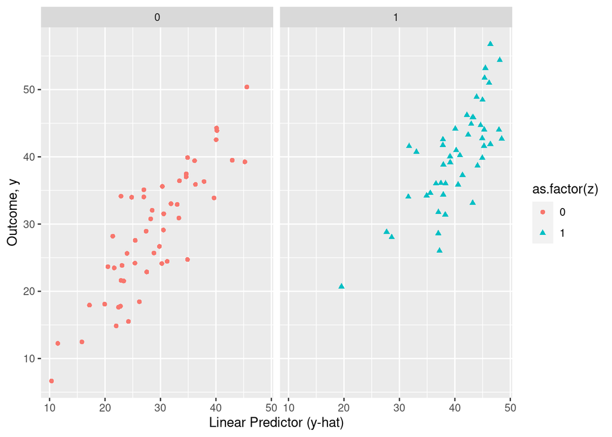

```r
#predicted is the y-hats, predicted values, using the model
#then we calculate the residuals as the actual value - the predicted value.
fake2 <- fake %>%
  mutate(predicted=predict(fit), resid=y-predict(fit))
ggplot(fake2, aes(x=predicted, y=y, shape=as.factor(z), color=as.factor(z)) )+
  geom_point() +
  facet_grid(. ~ as.factor(z)) +
 xlab("Linear Predictor (y-hat)") + ylab("Outcome, y")
```

#### Book Way for Predictor vs. Outcome

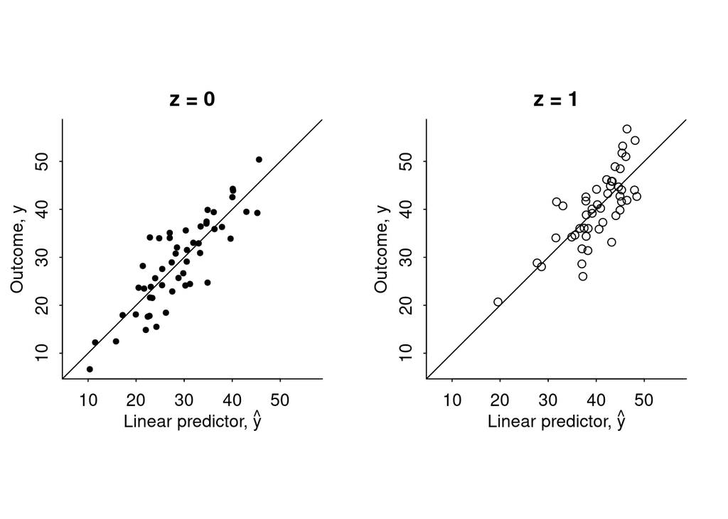

```r
y_hat <- predict(fit)
par(mfrow=c(1,2), mar=c(3,3,2,2), mgp=c(1.7,.5,0), tck=-.01)
par(mfrow=c(1,2), pty="s")
for (i in 0:1){
  plot(range(y_hat,y), range(y_hat,y), type="n", xlab=expression(paste("Linear predictor, ", hat(y))), ylab="Outcome, y", main=paste("z =", i), bty="l")
  points(y_hat[z==i], y[z==i], pch=20+i)
abline(0, 1)
}
```

#### Plot Predictor vs Residual

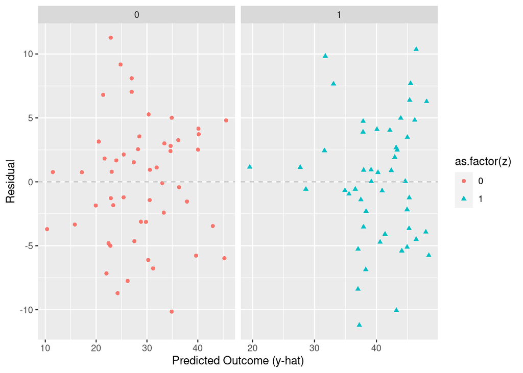

```r
#predicted is the y-hats, predicted values, using the model
#then we calculate the residuals as the actual value - the predicted value.

ggplot(fake2, aes(x=predicted, y=resid, shape=as.factor(z), color=as.factor(z)) )+
  geom_point() +
  geom_hline(yintercept=0, linetype="dashed", color = "gray") +
  facet_grid(. ~ as.factor(z), scales="free_x") +
 xlab("Predicted Outcome (y-hat)") + ylab("Residual")
```

#### What happens if there is Interaction but we miss it?

Below redo the simple example but add an interaction effect when you generate the fake data. set the coefficient for the interaction to 20. What do you observe?

Once you fit the model with out an interaction, add the interaction and take a look at how the plots change.

#### What happens if there is non-constant variance?

Below redo the simple example but make the variance non-constant for different levels of x when you make the fake data. The error term will be:

error $\sim$ N(0, function(x){1+0.5*x})